# YouTube Channel Performance

## Introduction

In this project, I focused on analyzing the performance of a YouTube channel over the span of one month. This project utilizes Python and the YouTube API for data extraction, and employs SQL queries for data analysis. The objective is to gain valuable insights into the channel's performance by examining key metrics such as views, likes, and engagement rate. The final result is a dashboard made on Power BI by doing queries in to the database from mySQL workbench.

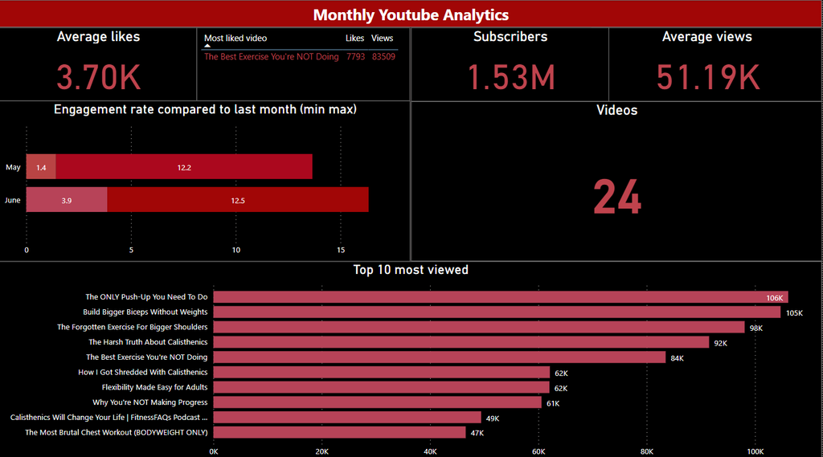

The project contains the top 10 videos with the highest number of views during the specified timeframe. This analysis allows to determine the most popular videos based on viewer engagement.

Additionally, I determined the video that received the highest number of likes within the given month. This metric provides an understanding of the level of audience appreciation for a specific video.

Calculating the average number of likes per video was done to help gauging the overall popularity and engagement level of the channel's content.

Similarly, the average number of views per video is computed to assess the reach and viewership of the channel's videos.

Furthermore, I examined the videos with the highest and lowest engagement rates for both the current and previous months. This analysis provides insights into the effectiveness of the channel's content in capturing and retaining viewer attention.

To enhance the presentation and comprehension of the data, the project includes visualizations created using Power BI. These interactive and visually appealing charts and graphs aid in conveying the findings effectively.

By analyzing the data and metrics mentioned above, this data analyst project aims to provide valuable insights into the performance and audience engagement of the YouTube channel. The findings can be utilized to make informed decisions and optimize content strategies to drive further growth and success.

I took a Youtube Channel called "Fitness FAQs" as an example and a video called "Should you take creatine?". The ID of the channel can be found directly on the channel page or by looking in the source code of the page.

## Initialization

```python
import pymysql
import os
from googleapiclient.discovery import build
import requests
import pandas as pd
import openai
from googleapiclient.errors import HttpError
import mysql.connector
from mysql.connector import Error
api_key = '***********'
```

## Youtube 1/2

- Function taking a Youtube Channel in parameter:
1. It creates a YouTube service instance using the provided API key.
2. It sends a request to the YouTube API to retrieve the statistics for the specified channel.
3. It extracts the relevant statistics such as view count, subscriber count, and video count from the API response.
4. It sends another request to get the playlist ID for the channel's uploaded videos.
5. It retrieves all the video IDs for the channel's uploaded videos using pagination.
6. It iterates through each video ID and sends a request to get the video statistics and snippet information.
7. It extracts the video title, like count, comment count, view count, engagement rate, and published date from the API response for each video.
8. It stores the extracted data in separate lists.
9. It creates a DataFrame using the collected data.
10. It converts the published date to the desired format (YYYY-MM-DD).
11. It returns the DataFrame containing the video statistics for the channel.

In summary, the function fetches the statistics and information for each video of a specified YouTube channel and organizes the data in a DataFrame.

Comment: The youtube API limits "maxResults" to 50 (meaning I could get only 50 videos) when retrieving the data. To get more data, I had to create a loop to take the tokens of the next page.

```python
def get_channel_video_statistics(channel_id):
    # Create a YouTube service instance
    youtube = build('youtube', 'v3', developerKey=api_key)

    # Get channel statistics
    channel_request = youtube.channels().list(
        part='statistics',
        id=channel_id
    )
    channel_response = channel_request.execute()
    channel_stats = channel_response['items'][0]['statistics']

    # Retrieve relevant statistics from the channel response
    view_count = int(channel_stats['viewCount'])
    subscriber_count = int(channel_stats['subscriberCount'])
    video_count = int(channel_stats['videoCount'])

    # Get the playlist ID for the channel's uploaded videos
    playlist_request = youtube.channels().list(
        part='contentDetails',
        id=channel_id
    )
    playlist_response = playlist_request.execute()
    playlist_id = playlist_response['items'][0]['contentDetails']['relatedPlaylists']['uploads']

    # Create a list to store all video IDs
    video_ids = []

    # Retrieve all the video IDs using pagination
    next_page_token = None

    while True:
        videos_request = youtube.playlistItems().list(
            part='snippet',
            playlistId=playlist_id,
            maxResults=50,
            pageToken=next_page_token
        )
        videos_response = videos_request.execute()

        video_ids += [item['snippet']['resourceId']['videoId'] for item in videos_response['items']]

        if 'nextPageToken' in videos_response:
            next_page_token = videos_response['nextPageToken']
        else:
            break

    # Create lists to store the video data
    video_titles = []
    like_counts = []
    comment_counts = []
    view_counts = []
    engagement_rates = []
    published_dates = []

    # Retrieve the video statistics for each video
    for video_id in video_ids:
        video_request = youtube.videos().list(
            part='statistics,snippet',
            id=video_id
        )
        video_response = video_request.execute()
        video_stats = video_response['items'][0]['statistics']
        video_snippet = video_response['items'][0]['snippet']

        video_title = video_snippet['title']
        like_count = int(video_stats.get('likeCount', 0))
        comment_count = int(video_stats.get('commentCount', 0))
        view_count = int(video_stats.get('viewCount', 0))
        engagement_rate = (like_count + comment_count) / view_count * 100
        published_date = video_snippet['publishedAt']

        video_titles.append(video_title)
        like_counts.append(like_count)
        comment_counts.append(comment_count)
        view_counts.append(view_count)
        engagement_rates.append(engagement_rate)
        published_dates.append(published_date)

    # Create a DataFrame from the collected data
    data = {
        'Video Title': video_titles,
        'Likes': like_counts,
        'Number of Comments': comment_counts,
        'Number of Views': view_counts,
        'Engagement Rate': engagement_rates,
        'Published Date': published_dates
    }
    df = pd.DataFrame(data)

    # Convert published date to desired format
    df['Published Date'] = pd.to_datetime(df['Published Date']).dt.strftime('%Y-%m-%d')

    # Add number of subscribers to DataFrame
    df['Number of Subscribers'] = subscriber_count

    return df
```

## Youtube 2/2

The given function `comments(video_title)` retrieves comments from a YouTube video using the YouTube Data API.

```python
def comments(video_title):
    youtube = build('youtube', 'v3', developerKey=api_key)

    # Request the search results
    search_response = youtube.search().list(
        part='id',
        q=video_title,
        type='video',
        maxResults=1
    ).execute()

    # Extract the video ID from the search results
    video_id = search_response['items'][0]['id']['videoId']

    # Request the comments for the video
    comments_response = youtube.commentThreads().list(
        part='snippet',
        videoId=video_id,
        textFormat='plainText',
        maxResults=100
    ).execute()

    comments_list = []

    # Process the comments
    for comment in comments_response['items']:
        snippet = comment['snippet']['topLevelComment']['snippet']
        author = snippet['authorDisplayName']
        text = snippet['textDisplay']
        likes = snippet['likeCount']
        published_at = snippet['publishedAt']
        comments_list.append([author, text, likes, published_at])

    # Create a DataFrame from the comments list
    df = pd.DataFrame(comments_list, columns=['Author', 'Comment', 'Likes', 'Published At'])
    df['VideoTitle'] = video_title

    # Convert published date to desired format
    df['Published At'] = pd.to_datetime(df['Published At']).dt.strftime('%Y-%m-%d')
    return df
```

## Open AI : Chat GPT API

Initially, I wanted to analyze the general sentiment of eqch video by giving each comment to Chat GPT.

I creating a function that wworks by taking each comment collecting in the dataframe in the previous function.

I have not used this part for the final dashboard because the API is not free. An improvement of this project would be to analyze all the comments of all videos to add the general sentiment per month to the dashboard.

The ChatGPT API is offered at USD 0.002 for 1000 tokens. In English, 1000 tokens represent approximately 750 words. So, if I need to generate a 750-word article in English, with a prompt of 250 words, it will cost approximately USD 0.0026.

It is convenient to use the GPT model because the AI:

- Can fine tune the analysis by changing the prompt
- Can give justification

```python
def gpt(df):
    openai.api_key = "API_KEY"

    # Iterate over the dataframe rows
    for index, row in df.iterrows():
        comment = row['Comment']

        # Define the prompt with the comment
        prompt = "This is a youtube comment. How would you describe it between positive/negative/neutral? Answer by giving the sentiment ONLY:"

        # Create the completion request
        completion = openai.ChatCompletion.create(
            model="gpt-3.5-turbo",
            messages=[
                {"role": "user", "content": prompt},
                {"role": "user", "content": comment}
            ]
        )

        # Extract the sentiment and words from the completion response
        sentiment = completion.choices[0]['message']['content']


        # Update the dataframe with the sentiment and words
        df.at[index, 'Sentiment'] = sentiment
```

## SQL (1/2)

In this part, I made a function to store the statistics data in MySQL Workbench from the dataframe collected with the first function in youtube 1/2.

The idea is to:

- Create the table in MySQL Workbench (if not alreadt existing)
- Store the data in the database table 'youtube' that is updated with the new values

```python
def sqlinit():
    # Connect to your MySQL database
    connection = pymysql.connect(
        host='localhost',
        user='root',
        password='Ale/*1547-++',
        database='youtube'
    )

    # Create table statistics
    statistics = """
    CREATE TABLE IF NOT EXISTS statistics (
        VideoTitle VARCHAR(255),
        Likes INT,
        NumComments INT,
        NumViews INT,
        EngagementRate FLOAT,
        PublishedDate DATE,
        NumSubscribers INT
    );
    """
    with connection.cursor() as cursor:
        cursor.execute(statistics)

        # Delete existing data
        cursor.execute("DELETE FROM statistics;")

        # Insert data into statistics
        statistics_data = df1.values.tolist()
        insert_statistics = """
        INSERT INTO statistics (VideoTitle, Likes, NumComments, NumViews, EngagementRate, PublishedDate, NumSubscribers)
        VALUES (%s, %s, %s, %s, %s, %s, %s);
        """
        cursor.executemany(insert_statistics, statistics_data)

    # Commit the changes and close the database connection
    connection.commit()
    connection.close()
```

## SQL (2/2)

On POWER BI, it's possible to get data from "MySQL" option and just write the query directly in POWER Query.

I first created and tested the queries in this jupyter notebook before using them in Power BI to make the Dashboard.

Remark: the last query 6 links the 'statistics' table to the 'comment' one by using a join. I have not used this query in the dashboard as I did not go further in the sentiment analysis. Also, I did not add the table to the database direclty with the previous function. I used the import option in MySQL workbench to get a CSV file that I created further in the code. The reason is that I needed to do some tests with the CHAT GPT API with small samples of data on Excel before adding it to the database.

```python
# connect to the MySQL database
%load_ext sql
%sql mysql+pymysql://root:*********@localhost/youtube
```

```python
%%sql

-- 1. Find the top 10 videos with the highest number of views.
-- SELECT * FROM statistics WHERE PublishedDate >= DATE_SUB(CURRENT_DATE(), INTERVAL 1 MONTH) ORDER BY NumViews DESC LIMIT 10;

-- 2. Find the video with the most likes.
-- SELECT * FROM statistics WHERE PublishedDate >= DATE_SUB(CURRENT_DATE(), INTERVAL 1 MONTH) ORDER BY Likes DESC LIMIT 1;

-- 3. Calculate the average number of likes per video.
-- SELECT AVG(`Likes`) AS AverageLikes FROM statistics WHERE PublishedDate >= DATE_SUB(CURRENT_DATE(), INTERVAL 1 MONTH);

-- 4. Calculate the average number of views per video.
-- SELECT AVG(`NumViews`) AS AverageViews FROM statistics WHERE PublishedDate >= DATE_SUB(CURRENT_DATE(), INTERVAL 1 MONTH);

-- 5. Retrieve the videos with the highest and lowest engagement rate for the current month and last month.
SELECT * FROM statistics WHERE `EngagementRate` = (SELECT MAX(`EngagementRate`) FROM statistics WHERE MONTH(PublishedDate) = MONTH(CURRENT_DATE()) AND YEAR(PublishedDate) = YEAR(CURRENT_DATE())) AND MONTH(PublishedDate) = MONTH(CURRENT_DATE()) AND YEAR(PublishedDate) = YEAR(CURRENT_DATE())
UNION
SELECT * FROM statistics WHERE `EngagementRate` = (SELECT MIN(`EngagementRate`) FROM statistics WHERE MONTH(PublishedDate) = MONTH(CURRENT_DATE()) AND YEAR(PublishedDate) = YEAR(CURRENT_DATE())) AND MONTH(PublishedDate) = MONTH(CURRENT_DATE()) AND YEAR(PublishedDate) = YEAR(CURRENT_DATE())
UNION
SELECT * FROM statistics WHERE `EngagementRate` = (SELECT MAX(`EngagementRate`) FROM statistics WHERE MONTH(PublishedDate) = MONTH(DATE_SUB(CURRENT_DATE(), INTERVAL 1 MONTH)) AND YEAR(PublishedDate) = YEAR(DATE_SUB(CURRENT_DATE(), INTERVAL 1 MONTH))) AND MONTH(PublishedDate) = MONTH(DATE_SUB(CURRENT_DATE(), INTERVAL 1 MONTH)) AND YEAR(PublishedDate) = YEAR(DATE_SUB(CURRENT_DATE(), INTERVAL 1 MONTH))
UNION
SELECT * FROM statistics WHERE `EngagementRate` = (SELECT MIN(`EngagementRate`) FROM statistics WHERE MONTH(PublishedDate) = MONTH(DATE_SUB(CURRENT_DATE(), INTERVAL 1 MONTH)) AND YEAR(PublishedDate) = YEAR(DATE_SUB(CURRENT_DATE(), INTERVAL 1 MONTH))) AND MONTH(PublishedDate) = MONTH(DATE_SUB(CURRENT_DATE(), INTERVAL 1 MONTH)) AND YEAR(PublishedDate) = YEAR(DATE_SUB(CURRENT_DATE(), INTERVAL 1 MONTH));

-- 6. Join the comment information to the video table
SELECT *
FROM statistics
JOIN comment ON statistics.VideoTitle = comment.VideoTitle;
```

```python
df1 = get_channel_video_statistics('UC1CVzH-XVr3E-kTT6D8hhfg')
df2 = comments('Should You Take Creatine?')
df3 = gpt(df2)
sqlinit()
```

```python
df3.to_csv("comment.csv")
```

## Power BI visualization

- Collecting the data in the SQL tables (get data from MySQL workbench and retrieve only what is necassary with SQL queries -> the one is the SQL 2/2 part)

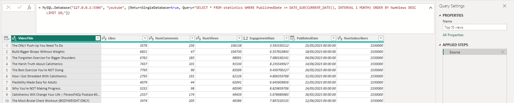

- Creating a dashboard to get the different KPI

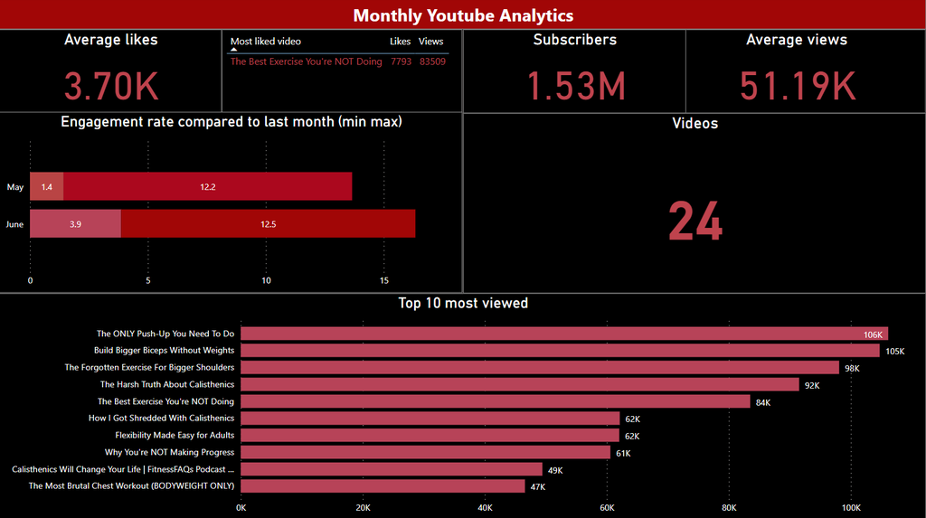

## Conclusion

In this project, I created a pipeline from Youtube using the API to a dashboard in Power BI. The idea is to get a fast data collection and processing to understand quickly what happened in the last month. This provides insights each month via some KPIs. By using functions, there is a lot of flexibility to process any youtbe channel or video taking the ID.

A usage could be:

- Verifying that certain values do not go under a treshold
- Checking what type of video get in the TOP 10
- Following the channel growth over the time -> To do so, the only thing to change would be the period (currently on month) in the queries and add a tiemeline component to the dashboard.

Further analysis could be done also to see the correlation between the views and like for a particular channel.